# Programming Assignment 1

N. G. Schwarz

Wednesday, June 10, 2015

## Introduction

This assignment makes use of data from a personal activity monitoring device. This device collects data of number of steps taken at 5 minute intervals through out the day. The data consists of two months of data from an anonymous individual collected during the months of October and November 2012.

The following analysis works on answering a few key exploratory questions:

- What is mean, median, and total number of steps taken per day?
- What is the average daily activity pattern?
- How to impute missing values?
- What differences are there between the original and imputed data?
- Are there differences in activity patterns between weekdays and weekends?

## Analysis

### Preprocessing

#### Reading Data

Downloading and reading the activity monitoring data

```r
URL <- "https://d396qusza40orc.cloudfront.net/repdata%2Fdata%2Factivity.zip"
download.file(URL, "zip", method = "curl")
file <- unzip("zip")
A <- read.csv(file)
```

#### NA Values

Ignoring NA Values in entire dataset

```r
A0 <- na.omit(A)
A0$date <- droplevels(A0$date)
```

**Note**, as consequence of removing NA values, the following days were completely removed from Date column in ‘A0’, as they had only NA values. These days will not taken into account for the first calculations of this assignment.

```r
days.kept <- which(unique(A$date) %in% unique(A0$date))
days.removed <- as.Date(unique(A$date)[-days.kept])
days.removed
```

```
## [1] "2012-10-01" "2012-10-08" "2012-11-01" "2012-11-04" "2012-11-09"
## [6] "2012-11-10" "2012-11-14" "2012-11-30"
```

### Calculations on Number of Steps per Day

#### Total Steps

Calculating the total number of steps taken per day

```r
totalByday <- aggregate(A0$steps, list(A0$date), sum)
colnames(totalByday) <- c("Date", "Total Steps")
totalByday
```

```
##          Date Total Steps
## 1  2012-10-02         126
## 2  2012-10-03       11352
## 3  2012-10-04       12116
## 4  2012-10-05       13294
## 5  2012-10-06       15420
## 6  2012-10-07       11015
## 7  2012-10-09       12811
## 8  2012-10-10        9900
## 9  2012-10-11       10304
## 10 2012-10-12       17382
## 11 2012-10-13       12426
## 12 2012-10-14       15098
## 13 2012-10-15       10139
## 14 2012-10-16       15084
```

[output cut: 39 more lines]

#### Histogram

Plotting a histogram of the total number of steps taken each day

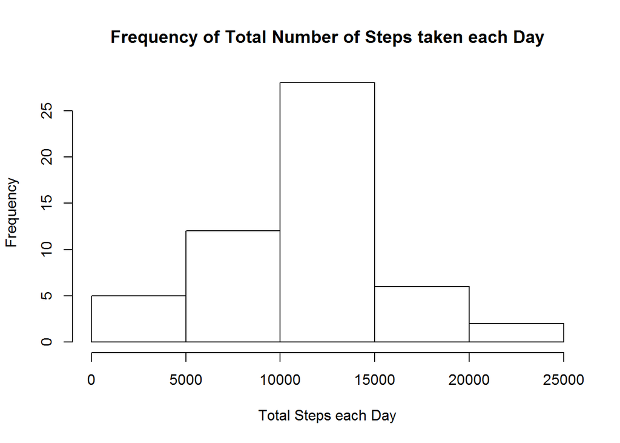

```r
hist(totalByday[, "Total Steps"],
     main = "Frequency of Total Number of Steps taken each Day",
     xlab = "Total Steps each Day")
```

#### Mean Steps

Calculating the mean of the total number of steps taken per day

```r
meanByday <- aggregate(A0$steps, list(A0$date), mean)
colnames(meanByday) <- c("Date", "Mean Steps")
meanByday[, "Mean Steps"] <- round(meanByday[, "Mean Steps"], 2)
meanByday
```

```
##          Date Mean Steps
## 1  2012-10-02       0.44
## 2  2012-10-03      39.42
## 3  2012-10-04      42.07
## 4  2012-10-05      46.16
## 5  2012-10-06      53.54
## 6  2012-10-07      38.25
## 7  2012-10-09      44.48
## 8  2012-10-10      34.38
## 9  2012-10-11      35.78
## 10 2012-10-12      60.35
## 11 2012-10-13      43.15
## 12 2012-10-14      52.42
## 13 2012-10-15      35.20
## 14 2012-10-16      52.38
```

[output cut: 39 more lines]

#### Median Steps

Calculating the median of the total number of steps taken per day

```r
medianByday <- aggregate(A0$steps, list(A0$date), median)
colnames(medianByday) <- c("Date", "Median Steps")
medianByday
```

```
##          Date Median Steps
## 1  2012-10-02            0
## 2  2012-10-03            0
## 3  2012-10-04            0
## 4  2012-10-05            0
## 5  2012-10-06            0
## 6  2012-10-07            0
## 7  2012-10-09            0
## 8  2012-10-10            0
## 9  2012-10-11            0
## 10 2012-10-12            0
## 11 2012-10-13            0
## 12 2012-10-14            0
## 13 2012-10-15            0
## 14 2012-10-16            0
```

[output cut: 39 more lines]

**Note**, median values are all zero (0). This might seem strange given the mean calculations were not near zero (0). It is important to recall that the median is the center value of an ordered distribution. This dataset has an overwhelming predominance of zeros in the distrubion of steps taken.

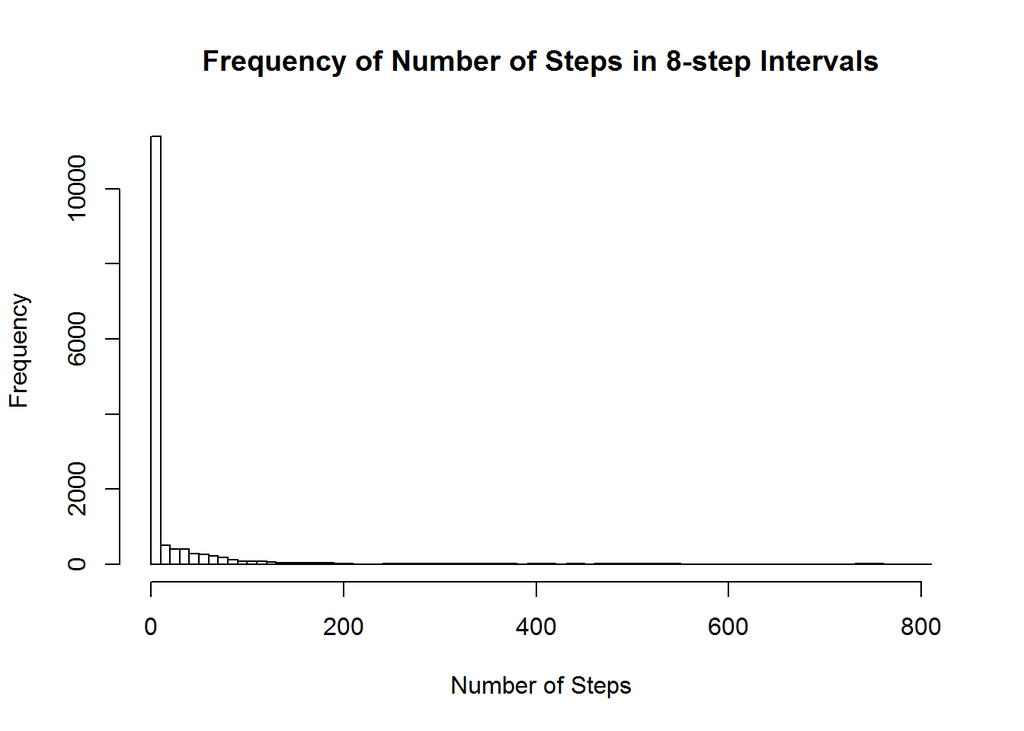

```r
hist(A0$steps, breaks = 100, xlab = "Number of Steps",
     main = "Frequency of Number of Steps in 8-step Intervals")
```

And even when zooming into the first 200 steps, to get a better picture of the gross of the distribution, steps not taken (0) are outpacingly more frequent than other values.

[figure not shown]

```r
hist(A0$steps, breaks = 100, xlim = c(0, 200), xlab = "Number of Steps",
     main = "Frequency of Number of Steps (between 0 and 200 steps)
     in 2-step Intervals")
```

Evidently, there are enough zeros for the distribution of steps per day, when ordered, to have a zero in its middle value, or median.

### Daily Activity Pattern

#### Time Series Plot

Making a time series plot of the 5-minute interval (x-axis) and the average number of steps taken, averaged across all days (y-axis)

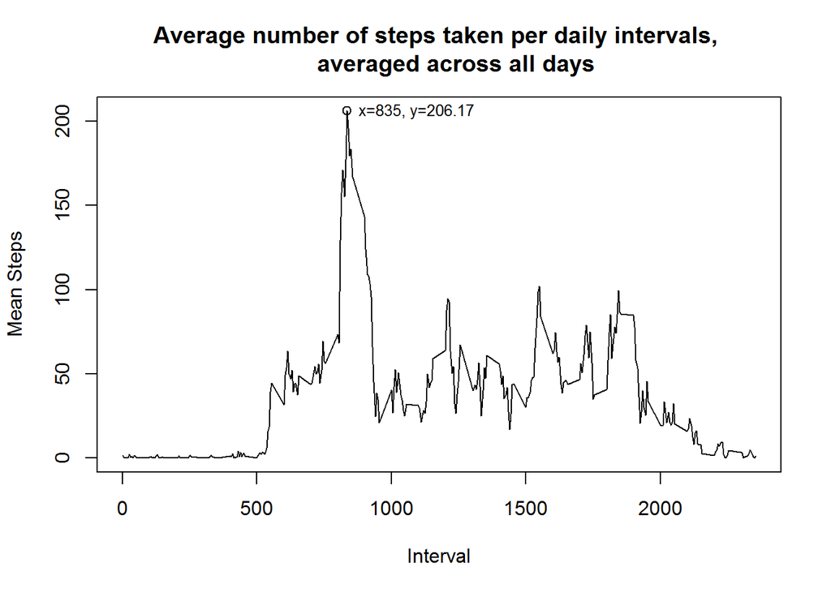

```r
meanByinterval <- aggregate(A0$steps, list(A0$interval), mean)
colnames(meanByinterval) <- c("Interval", "Mean Steps")
meanByinterval[, "Mean Steps"] <- round(meanByinterval[, "Mean Steps"], 2)
plot(meanByinterval, type = "l",
     main = "Average number of steps taken per daily intervals,
     averaged across all days")
points(x=835, y=206.17)
text(x=835, y=206.17, "x=835, y=206.17",pos=4, cex=0.8)
```

#### Greatest Step Interval

Finding the 5-minute interval which, on average across all the days in the dataset, contains the maximum number of steps

```r
max <- which.max(meanByinterval[, "Mean Steps"])
meanByinterval[max, ]
```

```
##     Interval Mean Steps
## 104      835     206.17
```

### Imputing Missing Values and Comparing Imputed to Omitted Datasets

#### Reporting Missing Values

Calculating and reporting the total number of missing values in steps

```r
sum(is.na(A$steps))
```

```
## [1] 2304
```

#### Imputation Method Selection

Imputation methods, such as regression imputation, offer more precise values (less noisy) than simpler methods. Unfortunately most multiple and stochastic imputation techniques require multiple variables useful for predicting the missing value. These methods are not applicable for a data set that only has one numeric variable ‘steps’ and two variables ‘date’ and ‘interval’ that do not offer numerical information in terms of ‘steps’. Both are practically categorical values.

Three other methods are possible. For one, the median value of steps per interval or days. As seen before, the median values by both interval and date grouping would lead to impute 0 values in all NA values.

```r
head(aggregate(A0$steps, list(A0$date), median), 5)
```

```
##      Group.1 x
## 1 2012-10-02 0
## 2 2012-10-03 0
## 3 2012-10-04 0
## 4 2012-10-05 0
## 5 2012-10-06 0
```

```r
head(aggregate(A0$steps, list(A0$interval), median), 5)
```

```
##   Group.1 x
## 1       0 0
## 2       5 0
## 3      10 0
## 4      15 0
## 5      20 0
```

Another possibility is to use the mean value of steps per days. This method carries great error (standard deviation) as throughout the day the steps per interval behave very differently. It is simply illogical to impute a mean value for an entire day in the space of a 5 minute interval missing value.

```r
head(aggregate(A0$steps, list(A0$date), sd), 5)
```

```
##      Group.1          x
## 1 2012-10-02   6.912816
## 2 2012-10-03 111.897882
## 3 2012-10-04 108.601541
## 4 2012-10-05 120.916458
## 5 2012-10-06 121.204632
```

Lastly, the best method available is to calculate the mean value of steps per interval across all days, just as was shown in the prior time series plot. Here, the variation between intervals is much lower.

```r
head(aggregate(A0$steps, list(A0$interval), sd), 5)
```

```
##   Group.1         x
## 1       0 7.9768351
## 2       5 2.4724902
## 3      10 0.9615239
## 4      15 1.0988845
## 5      20 0.5494423
```

It is pressumable then that activity (steps) throughout the day is similar from on day to the next, making this method the most appropiate and logical to impute missing values (NA).

#### Missing Value Imputation

The row location of the NAs and their respective interval are determined.

```r
nas <- which(is.na(A$steps))
int <- A[nas, "interval"]
```

Then, the mean per according interval (calculated previously into object ‘meanByinterval’) is saved in another vector.

```r
mean <- sapply(int, function(x) {
  subset(meanByinterval, Interval == x, "Mean Steps")
  })
mean <- as.vector(unlist(mean))
```

Finally, each NA value has its according mean per interval value imputed in a new dataset called ‘A1’.

```r
A1 <- A
A1[nas, ]$steps <- mean
```

#### Difference between ‘A0’ (missing values omitted) and ‘A1’ (missing values imputed)

The following graphs and statistics on ‘A1’ (dataset with imputed missing values) are compared to the previous plots and calculations in order to compare the effect of missing value imputation.

#### Comparing Histograms

Plotting two histograms of the total number of steps taken each day

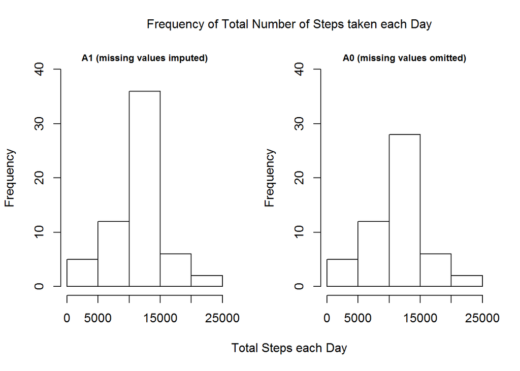

```r
par(mfrow = c(1, 2))
totalByday.1 <- aggregate(A1$steps, list(A1$date), sum)
colnames(totalByday.1) <- c("Date", "Total Steps")
hist(totalByday.1[, "Total Steps"],
     xlab = "",
     main = "",
     ylim = c(0,40))
title("A1 (missing values imputed)", cex.main = 0.75,line = 0)

totalByday <- aggregate(A0$steps, list(A0$date), sum)
colnames(totalByday) <- c("Date", "Total Steps")
hist(totalByday[, "Total Steps"],
     xlab = "",
     main = "",
     ylim = c(0,40))
title("A0 (missing values omitted)", cex.main = 0.75,line = 0)

par(mfrow = c(1, 1))
mtext("Frequency of Total Number of Steps taken each Day", side = 3, line = 2)
mtext("Total Steps each Day", side = 1, line = 3)
```

#### Comparing Mean and Median

Reporting the mean and median of the total number of steps per day for ‘A0’ and ‘A1’.

**Note**: In order to compare mean and median, merging the both datasets by the ‘date’ column is useful. However, the omission of rows with NA values caused dataset ‘A0’ to shrink from 17568 to 15264 rows. Dataset ‘A’ was used for these calculations, instead of ‘A0’, in order to pair up the rows perfectly by date.

#### Comparing Mean

```r
meanByday <- aggregate(A$steps, list(A$date), mean)
colnames(meanByday) <- c("Date", "Mean Steps")
meanByday[, "Mean Steps"] <- round(meanByday[, "Mean Steps"], 2)

meanByday.1 <- aggregate(A1$steps, list(A1$date), mean)
colnames(meanByday.1) <- c("Date", "Mean Steps with Imputation")
meanByday.1[, "Mean Steps with Imputation"] <- round(meanByday.1[, "Mean Steps with Imputation"], 2)

merge(meanByday, meanByday.1, by="Date")
```

```
##          Date Mean Steps Mean Steps with Imputation
## 1  2012-10-01         NA                      37.38
## 2  2012-10-02       0.44                       0.44
## 3  2012-10-03      39.42                      39.42
## 4  2012-10-04      42.07                      42.07
## 5  2012-10-05      46.16                      46.16
## 6  2012-10-06      53.54                      53.54
## 7  2012-10-07      38.25                      38.25
## 8  2012-10-08         NA                      37.38
## 9  2012-10-09      44.48                      44.48
## 10 2012-10-10      34.38                      34.38
## 11 2012-10-11      35.78                      35.78
## 12 2012-10-12      60.35                      60.35
## 13 2012-10-13      43.15                      43.15
## 14 2012-10-14      52.42                      52.42
```

[output cut: 47 more lines]

#### Comparing Median

```r
medianByday <- aggregate(A$steps, list(A$date), median)
colnames(medianByday) <- c("Date", "Median Steps")
medianByday[, "Median Steps"] <- round(medianByday[, "Median Steps"], 2)

medianByday.1 <- aggregate(A1$steps, list(A1$date), median)
colnames(medianByday.1) <- c("Date", "Median Steps with Imputation")
medianByday.1[, "Median Steps with Imputation"] <- round(medianByday.1[, "Median Steps with Imputation"], 2)

merge(medianByday, medianByday.1, by="Date")
```

```
##          Date Median Steps Median Steps with Imputation
## 1  2012-10-01           NA                        34.12
## 2  2012-10-02            0                         0.00
## 3  2012-10-03            0                         0.00
## 4  2012-10-04            0                         0.00
## 5  2012-10-05            0                         0.00
## 6  2012-10-06            0                         0.00
## 7  2012-10-07            0                         0.00
## 8  2012-10-08           NA                        34.12
## 9  2012-10-09            0                         0.00
## 10 2012-10-10            0                         0.00
## 11 2012-10-11            0                         0.00
## 12 2012-10-12            0                         0.00
## 13 2012-10-13            0                         0.00
## 14 2012-10-14            0                         0.00
```

[output cut: 47 more lines]

Both the median and mean value for ‘A1’ do not differ from the original dataset ‘A’. All values are identical, expect for, of course, the NA values which are now imputed values. This suggests that all NA values were found in entire days, not spread apart between days. (Remember, the mean and median were aggregated based on each day.) This congruent with the previous observation that, when NA values where omitted from ‘A’ into ‘A0’, entire days were excluded. This imputation proves unproblematic for the mean calculation, but not for the median. For the median, it does not take into account the overwhelming number of zeros found in other days, because the only values imputed were the mean steps per interval. Thus, this imputation is not efficient for the median. For the mean, given it is a central statistic that prioritizes the weight of observations over their position (order), the imputed values are reasonable to the behaviour of all other days.

### Differences between weekdays and weekends

#### Calling each day by Week Type

```r
week <- function(x) {
  y <- vector()
if(weekdays(as.Date(x)) == "Saturday") {
      y <- c(y, "weekend")
  } else if(weekdays(as.Date(x)) == "Sunday") {
      y <- c(y, "weekend")
  } else {
      y <- c(y, "weekday")
  }
return(y)
}

w <- as.factor(sapply(A1$date, week))
A1[, "weektype"] <- w
```

#### Comparing weekdays and weekends activity

Plotting a paneled time series plot to compare the steps per interval, averaged across days, between weekdays and weekends.

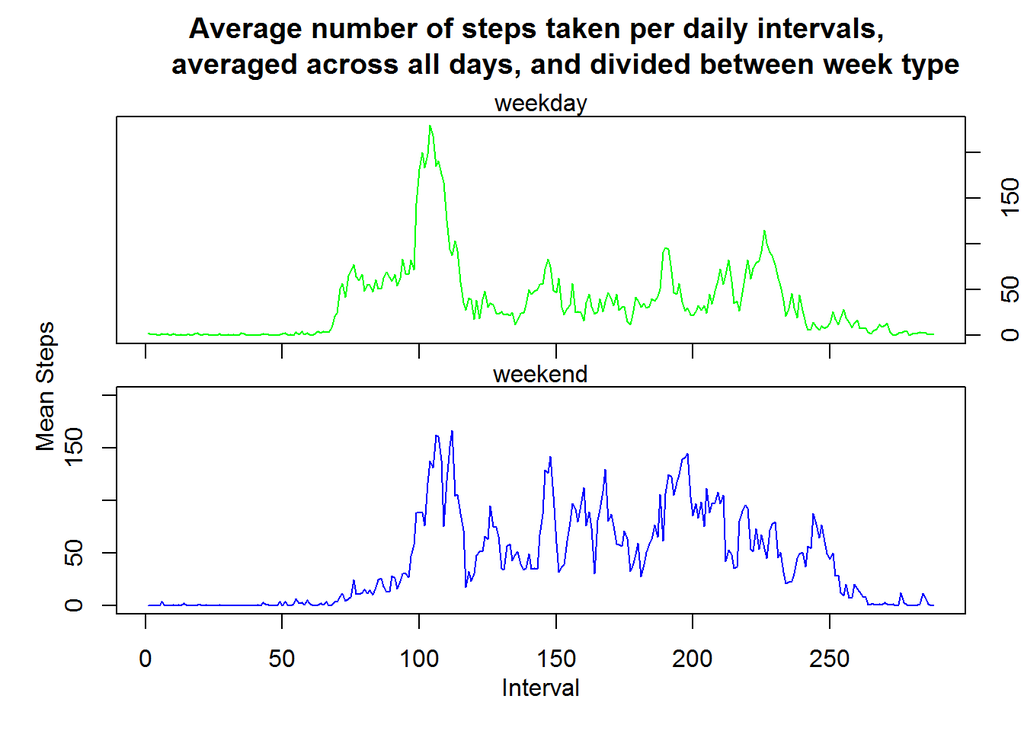

```r
meanByweektype <- aggregate(A1$steps, list(A1$interval, A1$weektype), mean)
colnames(meanByweektype) <- c("Interval", "Week_Type", "Mean Steps")
meanByweekday <- subset(meanByweektype, Week_Type == "weekday")
meanByweekend <- subset(meanByweektype, Week_Type == "weekend")

par(mfrow = c(2, 1))
par(mar = c(0, 0, 1.5, 0), oma = c(4, 4, 2.5, 2))
plot(meanByweekday[, "Mean Steps"], type = "l", col = "green", axes = F)
box()
mtext("weekday", 3)
axis(side = 4)
axis(side = 1, labels = F)
plot(meanByweekend[, "Mean Steps"], type = "l", col = "blue", ylim = c(0, 200))
mtext("weekend", 3)

par(mfrow = c(1, 1))
title("Average number of steps taken per daily intervals,
      averaged across all days, and divided between week type", line = 0, outer = T)
mtext("Mean Steps", 2, 2)
mtext("Interval", 1, 2)
```